# GAN_Monet

## Project Overview

The challenge revolves around utilizing Generative Adversarial Networks (GANs) to recreate the distinct artistic style of Claude Monet. We are tasked with building a GAN that generates 7,000 to 10,000 Monet-style images, employing both a generator and discriminator model that work against each other.

The ultimate goal is to create images so convincingly in Monet's style that classifiers cannot distinguish them from the real deal. This project not only celebrates the intersection of art and data science but also pushes the boundaries of what GANs can achieve in mimicking complex artistic nuances.

## Project Objectives

To tackle this challenge, one must first gain familiarity with the dataset and the intricacies of the Monet style.

The ultimate aim is to minimize the MiFID score, signaling high-quality, convincingly Monet-like generated images. The process involves iterative training and fine-tuning to outwit the discriminator and refine the generator’s artistic prowess.

## **Importing Libraries**

```python
import os
import numpy as np
import torch
import torch.nn as nn
from torch.nn.utils import clip_grad_norm_

from torch.utils.data import Dataset, DataLoader
import torchvision.transforms as transforms
from tqdm.notebook import tqdm

import matplotlib.pyplot as plt
from PIL import Image

import shutil
```

#### **Setting Seed and Device Configuration**

```python
seed = 420

np.random.seed(seed)
torch.manual_seed(seed)
torch.cuda.manual_seed(seed)
torch.backends.cudnn.deterministic = True

device = torch.device("cuda:0" if torch.cuda.is_available() else "cpu")
print(device)
```

```
cuda:0
```

## Explorative Data Analysis

Let's take a closer look at the Monet and Photo images to understand the dataset better.

Per competition descriptions, all the images for the competition are already sized to 256x256. As these images are RGB images, set the channel to 3.

```python
# Check image count

monet_dir = os.path.join(data_dir, 'monet_jpg')
photo_dir = os.path.join(data_dir, 'photo_jpg')

monet_files = [os.path.join(monet_dir, name) for name in sorted(os.listdir(monet_dir))]
monet_files.sort()
photo_files = [os.path.join(photo_dir, name) for name in sorted(os.listdir(photo_dir))]
photo_files.sort()

print(f"Number of Monet images: {len(monet_files)}")
print(f"Number of Photo images: {len(photo_files)}")
```

```
Number of Monet images: 300
Number of Photo images: 7038
```

[figure not shown]

```python
# Import and display sample images

sample_monet = Image.open(monet_files[0])
sample_photo = Image.open(photo_files[0])

fig, ax = plt.subplots(1, 2, figsize=(10, 5))
ax[0].imshow(sample_monet)
ax[0].axis('off')
ax[0].set_title('Monet')
ax[1].imshow(sample_photo)
ax[1].axis('off')
ax[1].set_title('Photo')
plt.show()
```

### Loading Monet and Photo Images

```python
class ImageDataset(Dataset):
    def __init__(self, data_dir, transforms=None):
        """
        Initializes the ImageDataset with directories containing Monet and photo images.

        Args:
            data_dir (str): Directory containing 'monet_jpg' and 'photo_jpg' subdirectories.
            transforms (callable, optional): A function/transform to apply to the images.
        """
        self.monet_dir = os.path.join(data_dir, 'monet_jpg')
        self.photo_dir = os.path.join(data_dir, 'photo_jpg')

        self.files_monet = [os.path.join(self.monet_dir, name) for name in sorted(os.listdir(self.monet_dir))]
        self.files_photo = [os.path.join(self.photo_dir, name) for name in sorted(os.listdir(self.photo_dir))]

        self.transforms = transforms

    def __len__(self):
        """
        Returns the number of Monet images in the dataset.

        Returns:
            int: Length of the dataset.
        """
        return len(self.files_monet)

    def __getitem__(self, index):
        """
        Retrieves a Monet image and a random photo image for the given index.

        Args:
            index (int): Index of the Monet image.

        Returns:
            tuple: Transformed Monet and photo images.
        """
        file_monet = self.files_monet[index]
        random_index = np.random.randint(0, len(self.files_monet))
        file_photo = self.files_photo[random_index]

        image_monet = Image.open(file_monet)
        image_photo = Image.open(file_photo)

        if self.transforms:
            image_monet = self.transforms(image_monet)
            image_photo = self.transforms(image_photo)

        return image_monet, image_photo
```

```python
# Dataset Directory and Batch Size
data_dir = 'gan-getting-started'
batch_size = 5
```

### Image preprocessing

Create a function to preprocess the images. To prepare images to train our model, we perform random flips and normalize the pixel values.

```python
# Data Preprocessing and DataLoader Initialization
transforms_ = transforms.Compose([
    transforms.RandomHorizontalFlip(p=0.5),
    transforms.RandomVerticalFlip(p=0.3),
    transforms.ToTensor(),
    transforms.Normalize(mean=(0.5, 0.5, 0.5), std=(0.5, 0.5, 0.5)),
])

dataloader = DataLoader(
    ImageDataset(data_dir, transforms=transforms_),
    batch_size=batch_size,
    shuffle=True,
    num_workers=2,
)
```

```
Clipping input data to the valid range for imshow with RGB data ([0..1] for floats or [0..255] for integers). Got range [-0.5764706..1.0].
Clipping input data to the valid range for imshow with RGB data ([0..1] for floats or [0..255] for integers). Got range [-1.0..0.79607844].
```

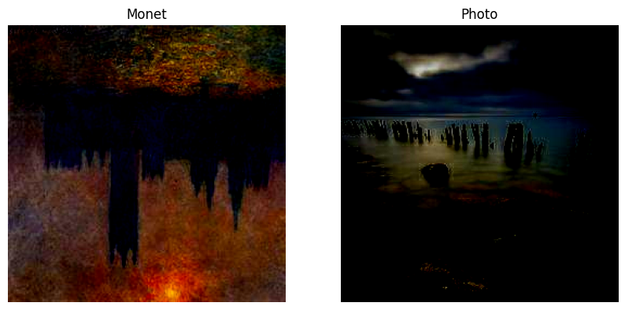

```python
# Visualize a photo and Monet image
monet, photo = next(iter(dataloader))
fig, ax = plt.subplots(1, 2, figsize=(10, 5))
ax[0].imshow(monet[0].permute(1, 2, 0))
ax[0].set_title('Monet')
ax[0].axis('off')
ax[1].imshow(photo[0].permute(1, 2, 0))
ax[1].set_title('Photo')
ax[1].axis('off')
plt.show()
```

```python
# Image Denormalization Function
def unnorm(img, mean=[0.5, 0.5, 0.5], std=[0.5, 0.5, 0.5]):
    for t, m, s in zip(img, mean, std):
        t.mul_(s).add_(s)
    return img
```

### Convolutional Block and Residual Block Classes

We define two custom neural network blocks: ConvBlock and ResidualBlock, which are essential components for building a Generative Adversarial Network (GAN) model. These blocks are designed to simplify the construction of convolutional neural networks by encapsulating common operations and configurations.

A. The ConvBlock class represents a modular convolutional block that includes several optional components such as transposed convolution, instance normalization, dropout, and activation functions. By parameterizing these components, we achieve flexibility and reusability for various network architectures. The design allows for easy customization, making it adaptable for different tasks within the GAN model.

1. Transposed Convolution: Optionally adds a transposed convolution layer, useful for upsampling in the generator model.
2. Instance Normalization: Normalizes the feature maps to improve convergence during training.
3. Dropout: Adds regularization to prevent overfitting.
4. Activation Functions: Uses either Leaky ReLU or ReLU to introduce non-linearity.

The block is converted into an nn.Sequential module to ensure a sequential flow of operations.

1. Reflection Padding: Pads the input to maintain spatial dimensions after convolution.
2. Skip Connection: Adds the input to the output of the block to create a shortcut path, helping to retain information and improve training stability.

These blocks are foundational for constructing the generator and discriminator networks within the GAN, ultimately enabling the generation of high-quality images in the style of Monet.

```python
class ConvBlock(nn.Module):
    def __init__(self, in_channels, out_channels, kernel_size=3, stride=1, padding=0,
                 transpose=False, use_leaky=True, use_dropout=False, normalize=True):
        """
        Initializes the ConvBlock with specified parameters.

        Args:
            in_channels (int): Number of input channels.
            out_channels (int): Number of output channels.
            kernel_size (int, optional): Size of the convolving kernel. Default is 3.
            stride (int, optional): Stride of the convolution. Default is 1.
            padding (int, optional): Zero-padding added to both sides of the input. Default is 0.
            transpose (bool, optional): Whether to use transposed convolution. Default is False.
            use_leaky (bool, optional): Whether to use Leaky ReLU activation. Default is True.
            use_dropout (bool, optional): Whether to use dropout. Default is False.
            normalize (bool, optional): Whether to use instance normalization. Default is True.
        """
        super(ConvBlock, self).__init__()

        layers = []
        if transpose:
            layers.append(nn.ConvTranspose2d(in_channels, out_channels, kernel_size, stride, padding, output_padding=1))
        else:
            layers.append(nn.Conv2d(in_channels, out_channels, kernel_size, stride, padding, bias=True))

        if normalize:
            layers.append(nn.InstanceNorm2d(out_channels))

        if use_dropout:
            layers.append(nn.Dropout(0.5))

        if use_leaky:
            layers.append(nn.LeakyReLU(negative_slope=0.2, inplace=True))
        else:
            layers.append(nn.ReLU(inplace=True))

        self.block = nn.Sequential(*layers)

    def forward(self, x):
        return self.block(x)

class ResidualBlock(nn.Module):
    def __init__(self, channels):
        """
        Initializes the ResidualBlock with specified number of channels.

        Args:
            channels (int): Number of channels for the convolutional layers.
        """
        super(ResidualBlock, self).__init__()
        self.block = nn.Sequential(
            nn.ReflectionPad2d(1),
            ConvBlock(in_channels=channels, out_channels=channels, kernel_size=3, use_leaky=False, use_dropout=True),
            nn.ReflectionPad2d(1),
            nn.Conv2d(in_channels=channels, out_channels=channels, kernel_size=3),
            nn.InstanceNorm2d(channels)
        )

    def forward(self, x):
        return x + self.block(x)
```

### Generator Network

The generator network is a crucial component of the Generative Adversarial Network (GAN) model, responsible for transforming input images into Monet-style images. The generator architecture is designed to learn the artistic style of Claude Monet and generate images that closely resemble his paintings.

The Generator class consists of three main parts: the encoder, the transformer, and the decoder.

1. Encoder: The encoder initially processes the input image with reflection padding and a convolutional block. It then down-samples the image through a series of convolutional layers to capture the high-level features of the image.
2. Transformer: The transformer applies a series of residual blocks to the encoded features, allowing for the incorporation of complex artistic details and ensuring the network can generate realistic Monet-style images.
3. Decoder: The decoder upsamples the transformed features back to the original image size, using transposed convolutional layers. The final output layer applies reflection padding, a convolutional layer, and a Tanh activation function to produce the final generated image.

```python
class Generator(nn.Module):
    def __init__(self, in_channels, out_channels, num_residual_blocks=9):
        super(Generator, self).__init__()

        # Encoder
        self.initial = nn.Sequential(
            nn.ReflectionPad2d(in_channels),
            ConvBlock(in_channels=in_channels, out_channels=64, kernel_size=2*in_channels+1, use_leaky=False)
        )

        self.down = nn.Sequential(
            ConvBlock(in_channels=64, out_channels=128, kernel_size=3, stride=2, padding=1, use_leaky=False),
            ConvBlock(in_channels=128, out_channels=256, kernel_size=3, stride=2, padding=1, use_leaky=False)
        )

        # Transformer
        self.transform = nn.Sequential(
            *[ResidualBlock(256) for _ in range(num_residual_blocks)]
        )

        # Decoder
        self.up = nn.Sequential(
            ConvBlock(in_channels=256, out_channels=128, kernel_size=3, stride=2, padding=1, transpose=True, use_leaky=False),
            ConvBlock(in_channels=128, out_channels=64, kernel_size=3, stride=2, padding=1, transpose=True, use_leaky=False)
        )

        self.out = nn.Sequential(
            nn.ReflectionPad2d(out_channels),
            nn.Conv2d(in_channels=64, out_channels=out_channels, kernel_size=2*out_channels+1),
            nn.Tanh()
        )

    def forward(self, x):
        x = self.initial(x)       # Encode
        x = self.down(x)          # Encode
        x = self.transform(x)     # Transform
        x = self.up(x)            # Decode
        x = self.out(x)           # Decode
        return x
```

### Discriminator Network for Image Discrimination with Convolutional Blocks

It is created per requirement to discriminate between real and generated images. The discriminator network is a key component of the Generative Adversarial Network (GAN) model, responsible for distinguishing between authentic Monet-style images and generated images. The discriminator architecture is designed to learn the differences between real and generated images, enabling it to provide feedback to the generator network during training.

```python
class Discriminator(nn.Module):
    def __init__(self, in_channels):
        super(Discriminator, self).__init__()

        self.model = nn.Sequential(
            # 3*256*256 -> 64*128*128
            ConvBlock(in_channels=in_channels, out_channels=64, kernel_size=4,
                      stride=2, padding=1, normalize=False),

            # 64*128*128 -> 128*64*64
            ConvBlock(in_channels=64, out_channels=128, kernel_size=4, stride=2, padding=1),

            # 128*64*64 -> 256*32*32
            ConvBlock(in_channels=128, out_channels=256, kernel_size=4, stride=2, padding=1),

            # 256*32*32 -> 512*31*31
            ConvBlock(in_channels=256, out_channels=512, kernel_size=4, stride=1, padding=1),

            # 512*31*31 -> 1*30*30
            nn.Conv2d(in_channels=512, out_channels=1, kernel_size=4, stride=1, padding=1),
        )


    def forward(self, x):
        return self.model(x)
```

```python
# Create a generator for converting images from the Monet domain to the Photo domain
generator_monet2photo = Generator(in_channels=3, out_channels=3, num_residual_blocks=9).to(device)

# Create a generator for converting images from the Photo domain to the Monet domain
generator_photo2monet = Generator(in_channels=3, out_channels=3, num_residual_blocks=9).to(device)

# Create a discriminator for distinguishing real and fake Monet images
discriminator_monet = Discriminator(in_channels=3).to(device)

# Create a discriminator for distinguishing real and fake Photo images
discriminator_photo = Discriminator(in_channels=3).to(device)

# Define the criterion for the GAN loss, which is mean squared error (MSE) loss
criterion_GAN = nn.MSELoss()

# Define the criterion for the cycle consistency loss, which is L1 loss
criterion_cycle = nn.L1Loss()

# Define the criterion for the identity loss, which is L1 loss
criterion_identity = nn.L1Loss()
```

#### **Optimizer Initialization and Configuration for Generators and Discriminators**

```python
# Set the learning rate for the optimizers
lr = 2e-4

# Set the values for the beta parameters used in the Adam optimizer
b1 = 0.5
b2 = 0.999

# Create an optimizer for the generator networks
optim_generators = torch.optim.Adam(
    list(generator_monet2photo.parameters()) + list(generator_photo2monet.parameters()),
    lr=lr, betas=(b1, b2)
)

# Create an optimizer for the discriminator networks
optim_discriminators = torch.optim.Adam(
    list(discriminator_monet.parameters()) + list(discriminator_photo.parameters()),
    lr=lr, betas=(b1, b2)
)
```

#### **Learning Rate Scheduling for Generators and Discriminators**

```python
# Set the total number of epochs for training
num_epochs = 10

# Set the epoch at which the learning rate starts to decay
decay_epoch = 3

# Define a lambda function to compute the learning rate schedule
lr_sched_step = lambda epoch: 1 - max(0, epoch - decay_epoch) / (num_epochs - decay_epoch)

# Create a learning rate scheduler for the generator optimizers
lr_sched_generators = torch.optim.lr_scheduler.LambdaLR(optim_generators, lr_lambda=lr_sched_step)

# Create a learning rate scheduler for the discriminator optimizers
lr_sched_discriminators = torch.optim.lr_scheduler.LambdaLR(optim_discriminators, lr_lambda=lr_sched_step)
```

#### **History Class for Tracking and Visualizing Losses**

```python
# A class for tracking and visualizing training history
class History:
    def __init__(self):
        self.generators_loss = []  # List to store generator losses
        self.discriminators_loss = []  # List to store discriminator losses

    # Method to update the history with generator and discriminator losses
    def update(self, gen_loss, discr_loss):
        self.generators_loss.append(gen_loss)
        self.discriminators_loss.append(discr_loss)

    # Method to display the loss history graph
    def show(self, title='Losses'):
        fig = plt.figure(figsize=(20, 8))
        plt.title(title)
        plt.plot(self.generators_loss, 'o-', color='r',
                 linewidth=2, markersize=3, label='Generators Loss')
        plt.plot(self.discriminators_loss, 'o-', color='b',
                 linewidth=2, markersize=3, label='Discriminators Loss')
        plt.legend(loc='best')
        plt.xlabel('Epochs')
        plt.ylabel('Loss')
        plt.grid(True)
        plt.show()
```

#### **Buffer Class for Managing and Sampling Images**

```python
# A class for managing a buffer of images
class Buffer:
    def __init__(self, max_images=50):
        self.max_images = max_images  # Maximum number of images to store in the buffer
        self.images = []  # List to store the images

    # Method to update the buffer with new images
    def update(self, images):
        images = images.detach().cpu().data.numpy()  # Convert images to numpy array
        for image in images:
            if len(self.images) < self.max_images:
                self.images.append(image)  # Append the image to the buffer if not full
            else:
                if np.random.rand() > 0.5:
                    index = np.random.randint(0, self.max_images)  # Randomly select an index
                    self.images[index] = image  # Replace the image at the selected index with the new image

    # Method to sample a specified number of images from the buffer
    def sample(self, num_images):
        samples = np.array([self.images[np.random.randint(0, len(self.images))]
                            for _ in range(num_images)])  # Randomly select images from the buffer
        return torch.tensor(samples)  # Convert the sampled images to a PyTorch tensor
```

```python
# Function to update the requires_grad attribute of model parameters
def update_req_grad(models, requires_grad=True):
    for model in models:
        for param in model.parameters():
            param.requires_grad = requires_grad
```

## Training CycleGAN Models with Discriminator and Generator Updates

The training process for this GAN involves alternating between training the generator and discriminator networks. The goal is to train the generators to create Monet-style images from photos and vice versa, while training the discriminators to distinguish between real and generated images.

```
Epoch: 1/10 | Generators Loss: 5.1999 | Discriminators Loss: 0.6743
```

```
Epoch: 2/10 | Generators Loss: 4.6352 | Discriminators Loss: 0.5885
```

```
Epoch: 3/10 | Generators Loss: 4.2326 | Discriminators Loss: 0.4546
```

```
Epoch: 4/10 | Generators Loss: 4.0703 | Discriminators Loss: 0.6360
```

```
Epoch: 5/10 | Generators Loss: 3.7615 | Discriminators Loss: 0.4308
```

```
Epoch: 6/10 | Generators Loss: 3.5445 | Discriminators Loss: 0.3856
```

```
Epoch: 7/10 | Generators Loss: 3.5550 | Discriminators Loss: 0.3178
```

```
Epoch: 8/10 | Generators Loss: 3.3237 | Discriminators Loss: 0.2701
```

```
Epoch: 9/10 | Generators Loss: 3.2176 | Discriminators Loss: 0.2697
```

```
Epoch: 10/10 | Generators Loss: 3.2038 | Discriminators Loss: 0.2600
```

[figure not shown]

```python
history = History()
buffer_monet = Buffer()
buffer_photo = Buffer()

for epoch in range(num_epochs):
    avg_generators_loss = 0
    avg_discriminators_loss = 0

    for i, (real_monet, real_photo) in enumerate(tqdm(dataloader, leave=False, total=len(dataloader))):
        real_monet, real_photo = real_monet.to(device), real_photo.to(device)

        """ Train Generators """
        # Enable gradients for generators, disable for discriminators
        update_req_grad([generator_monet2photo, generator_photo2monet], True)
        update_req_grad([discriminator_monet, discriminator_photo], False)

        # Zero gradients for generator optimizers
        optim_generators.zero_grad()

        # Forward pass for generators
        fake_photo = generator_monet2photo(real_monet)
        fake_monet = generator_photo2monet(real_photo)

        cycle_photo = generator_monet2photo(fake_monet)
        cycle_monet = generator_photo2monet(fake_photo)

        identity_photo = generator_monet2photo(real_photo)
        identity_monet = generator_photo2monet(real_monet)

        # Update buffers with fake images
        buffer_photo.update(fake_photo)
        buffer_monet.update(fake_monet)

        # Discriminator outputs for adversarial loss
        discriminator_outputs_photo = discriminator_photo(fake_photo)
        discriminator_outputs_monet = discriminator_monet(fake_monet)

        # Labels for adversarial loss
        labels_real = torch.ones(discriminator_outputs_monet.size()).to(device)
        labels_fake = torch.zeros(discriminator_outputs_monet.size()).to(device)

        # Compute adversarial loss
        loss_GAN_monet2photo = criterion_GAN(discriminator_outputs_photo, labels_real)
        loss_GAN_photo2monet = criterion_GAN(discriminator_outputs_monet, labels_real)
        loss_GAN = (loss_GAN_monet2photo + loss_GAN_photo2monet) / 2

        # Compute cycle consistency loss
        loss_cycle_photo = criterion_cycle(cycle_photo, real_photo)
        loss_cycle_monet = criterion_cycle(cycle_monet, real_monet)
        loss_cycle = (loss_cycle_photo + loss_cycle_monet) / 2

        # Compute identity mapping loss
        loss_identity_photo = criterion_identity(identity_photo, real_photo)
        loss_identity_monet = criterion_identity(identity_monet, real_monet)
        loss_identity = (loss_identity_photo + loss_identity_monet) / 2

        # Total generator loss
        loss_generators_total = loss_GAN + 10 * loss_cycle + 5 * loss_identity

        # Backward pass and optimization for generators
        loss_generators_total.backward()
        optim_generators.step()

        # Clip gradient norms for generators
        clip_grad_norm_(generator_photo2monet.parameters(), 100)
        clip_grad_norm_(generator_monet2photo.parameters(), 100)


        """ Train Discriminators """
        # Enable gradients for discriminators, disable for generators
        update_req_grad([discriminator_monet, discriminator_photo], True)
        update_req_grad([generator_monet2photo, generator_photo2monet], False)

        # Zero gradients for discriminator optimizers
        optim_discriminators.zero_grad()

        # Sample fake images from buffers
        fake_photo = buffer_photo.sample(num_images=batch_size).to(device)
        fake_monet = buffer_monet.sample(num_images=batch_size).to(device)

        # Compute noisy labels for real images
        threshold = min(1, 0.85 + (1 - 0.85) * epoch / (num_epochs // 2))
        noisy_labels_real = (torch.rand(discriminator_outputs_monet.size()) < threshold).float().to(device)

        # Compute losses for real and fake images
        loss_real_photo = criterion_GAN(discriminator_photo(real_photo), noisy_labels_real)
        loss_fake_photo = criterion_GAN(discriminator_photo(fake_photo.detach()), labels_fake)
        loss_photo = (loss_real_photo + loss_fake_photo) / 2

        loss_real_monet = criterion_GAN(discriminator_monet(real_monet), noisy_labels_real)
        loss_fake_monet = criterion_GAN(discriminator_monet(fake_monet.detach()), labels_fake)
        loss_monet = (loss_real_monet + loss_fake_monet) / 2

        # Total discriminator loss
        loss_discriminators_total = loss_monet + loss_photo

        # Backward pass and optimization for discriminators
        loss_discriminators_total.backward()
        optim_discriminators.step()

        # Clip gradient norms for discriminators
        clip_grad_norm_(discriminator_monet.parameters(), 100)
        clip_grad_norm_(discriminator_photo.parameters(), 100)

        # Update intermediate results
        avg_generators_loss += loss_generators_total.item()
        avg_discriminators_loss += loss_discriminators_total.item()

    # Save intermediate results
    avg_generators_loss /= len(dataloader)
    avg_discriminators_loss /= len(dataloader)
    history.update(avg_generators_loss, avg_discriminators_loss)

    # Print intermediate results
    print("Epoch: %d/%d | Generators Loss: %.4f | Discriminators Loss: %.4f"
          % (epoch+1, num_epochs, avg_generators_loss, avg_discriminators_loss))

    # Display generated images every 10 epochs
    if (epoch + 1) % 10 == 0:
        _, sample_real_photo = next(iter(dataloader))

        sample_fake_monet = generator_photo2monet(sample_real_photo.to(device)).detach().cpu()

        num_photos = min(batch_size, 5)
        plt.figure(figsize=(20, 8))
        for k in range(num_photos):
            plt.subplot(2, num_photos, k + 1)
            plt.imshow(unnorm(sample_real_photo[k]).permute(1, 2, 0))
            plt.title('Input photo')
            plt.axis('off')

            plt.subplot(2, num_photos, k + num_photos + 1)
            plt.imshow(unnorm(sample_fake_monet[k]).permute(1, 2, 0))
            plt.title('Output image')
            plt.axis('off')
        plt.show()

    # Update learning rates
    lr_sched_generators.step()
    lr_sched_discriminators.step()
```

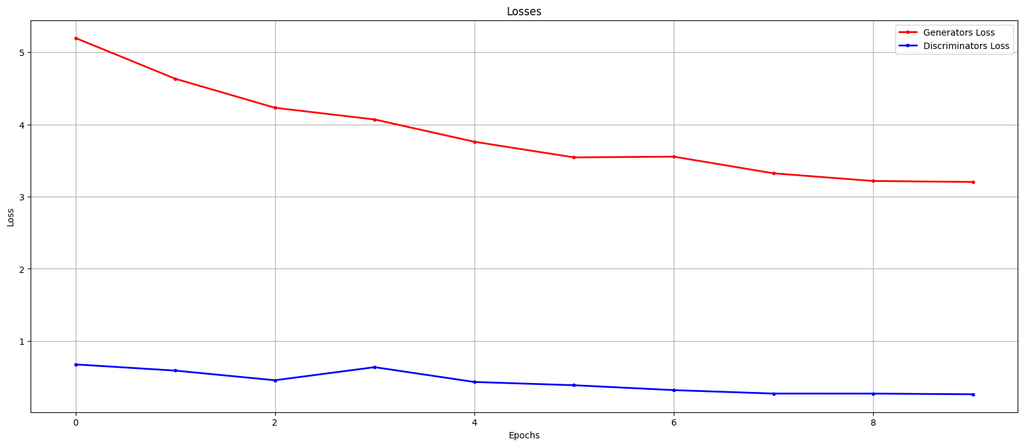

```python
# assessing the convergence and performance of the model during training.
history.show()
```

## Evaluation on performance:

- Generator: Generator loss decreases from 5.20 to 3.20 over increasing Epochs. The decreasing trend in the generator's loss indicates that the generators are improving over time. As the training progresses, the generators become better at creating images that resemble the target style, resulting in lower loss values.
- Discriminator: Discriminator loss decrease from 0.67 to 0.26 over increasing Epochs, indicating that the discriminators are also improving. They are getting better at distinguishing between real and fake images. The decrease in discriminator loss suggests that the discriminators are becoming more confident in their classifications and are more effectively identifying fake images generated by the generators.

## **Submission**

```python
photo_dir = os.path.join(data_dir, 'photo_jpg')
files = [os.path.join(photo_dir, name) for name in os.listdir(photo_dir)]
len(files)
```

```
7038
```

```python
save_dir = '../images'
if not os.path.exists(save_dir):
    os.makedirs(save_dir)
```

```python
# NB: Here we use generator training mode to provide noise in the form of dropout

generate_transforms = transforms.Compose([
    transforms.ToTensor(),
    transforms.Normalize((0.5, 0.5, 0.5), (0.5, 0.5, 0.5))
])

for i in range(0, len(files), batch_size):
    images = []
    for j in range(i, min(len(files), i + batch_size)):
        image = Image.open(files[j])
        image = generate_transforms(image)
        images.append(image)
    real_photo = torch.stack(images, 0)

    fake_images = generator_photo2monet(real_photo.to(device)).detach().cpu()

    for j in range(fake_images.size(0)):
        img = unnorm(fake_images[j])
        img = transforms.ToPILImage()(img).convert("RGB")
        img.save(os.path.join(save_dir, str(i + j + 1) + ".jpg"))
```

```python
shutil.make_archive("/kaggle/working/images", 'zip', "/kaggle/images")
```

```
'images.zip'
```

[figure not shown]

## Conclusion

### Evaluation of overall result and Hyperparameter "Tuning" (Kind of)

The public score of this model is 84.10, which is only average among the leaderboard. When I compare with some of the best models out there, I can see that the model is not performing well.

The model can be improved by tuning the hyperparameters and training for more epochs. The model can also be improved by using a different architecture or adding more layers to the generator and discriminator networks. The model can also be improved by using a different loss function or optimizer.

Since training a single iteration of the model takes a lot of time, I am unable to try out different hyperparameters and architectures using traditional methods like random search or grid search. Therefore, given more time, I will manually compare my model with other models on the leaderboard and try to understand what makes them better. I then try to incorporate those changes into my model.

One example of comparing hyperparameter used is with the recommend tutorial by the competition itself:

https://www.kaggle.com/code/amyjang/monet-cyclegan-tutorial

### Key differences:

1. Generators: Amy utilizes a U-Net-based architecture with residual blocks. U-Net architecture includes skip connections that help in preserving spatial information, which can be beneficial for generating high-quality images.
2. Discriminators: Amy uses PatchGAN discriminators, which focus on classifying local image patches rather than the entire image. This approach can provide more detailed feedback to the generator, leading to better image quality.
3. Noisy labels: Amy didn't use noisy labels for the discriminator.
4. Data Augmentation: Amy used more data augmentation techniques such as random flipping and rotation to increase the diversity of the training data.

From their last epoch:

```
300/300 [==============================] - 38s 126ms/step - photo_gen_loss: 2.7123 - monet_gen_loss: 2.6333 - photo_disc_loss: 0.6297 - monet_disc_loss: 0.6352
```

The image generator loss is around 2.6-2.7, which is lower than my model. This indicates that their model is better at generating Monet-style images.

### Why noisy labels didn't work well?

Noisy labels can introduce errors in the training process, leading to suboptimal performance. In the context of GANs, noisy labels can confuse the discriminator, making it harder for the generator to learn the target distribution. This can result in poor image quality and slower convergence during training.

In the future, I will try to incorporate these changes into my model and see if it improves the performance.

### Learnings and takeaways

This project has been a great learning experience for me. I have learned a lot about Generative Adversarial Networks (GANs) and how they can be used to generate images in the style of a particular artist. It is my first time using 2 different models to train against each other and I have learned a lot about how to train and evaluate these models.